# Consumer_Finance_Complaints_Keras_text

```python
import numpy as np
import pandas as pd

# sklearn
from sklearn  import metrics
from sklearn.model_selection import train_test_split, GridSearchCV, RandomizedSearchCV, cross_val_score, KFold
from sklearn.preprocessing import LabelBinarizer, LabelEncoder

# Tensorflow
import tensorflow as tf
from tensorflow import keras
from tensorflow.keras import layers

# Visualisation libraries

## Text
from colorama import Fore, Back, Style
from IPython.display import Image, display, Markdown, Latex, clear_output

## plotly
from plotly.offline import init_notebook_mode, iplot
import plotly.graph_objs as go
import plotly.offline as py
from plotly.subplots import make_subplots
import plotly.express as px

%matplotlib inline

import warnings
warnings.filterwarnings("ignore")
```

[Home](https://hatefdastour.github.io/) / [Natural Language Processing](https://hatefdastour.github.io/portfolio/natural_language_processing/)

## Consumer Complaint Database

- [**Exploratory Data Analysis**](https://hatefdastour.github.io/portfolio/natural_language_processing/Consumer_Finance_Complaints_EDA.html)
- [**Modeling: Keras Text Classification**](https://hatefdastour.github.io/portfolio/natural_language_processing/Consumer_Finance_Complaints_Keras_text.html)

**Consumer Complaint Database**

In this article, we use the [Consumer Complaint Database](https://catalog.data.gov/dataset/consumer-complaint-database) published by [Consumer Financial Protection Bureau](https://catalog.data.gov/dataset?publisher=Consumer%20Financial%20Protection%20Bureau).

## Data Description

According to [Kaggle page](https://www.kaggle.com/cfpb/us-consumer-finance-complaints) of Consumer Financial Protection Bureau (CFPB), Each week the [CFPB](https://www.consumerfinance.gov/) sends thousands of consumers’ complaints about financial products and services to companies for response. Those complaints are published here after the company responds or after 15 days, whichever comes first. By adding their voice, consumers help improve the financial marketplace.

```python
Data = pd.read_csv('ccdatabase/complaints.csv')
Data.head(3)
```

|  | Date received | Product | Sub-product | Issue | Sub-issue | Consumer complaint narrative | Company public response | Company | State | ZIP code | Tags | Consumer consent provided? | Submitted via | Date sent to company | Company response to consumer | Timely response? | Consumer disputed? | Complaint ID |
| --- | --- | --- | --- | --- | --- | --- | --- | --- | --- | --- | --- | --- | --- | --- | --- | --- | --- | --- |
| 0 | 2019-09-24 | Debt collection | I do not know | Attempts to collect debt not owed | Debt is not yours | transworld systems inc. \nis trying to collect... | NaN | TRANSWORLD SYSTEMS INC | FL | 335XX | NaN | Consent provided | Web | 2019-09-24 | Closed with explanation | Yes | NaN | 3384392 |
| 1 | 2019-09-19 | Credit reporting, credit repair services, or o... | Credit reporting | Incorrect information on your report | Information belongs to someone else | NaN | Company has responded to the consumer and the ... | Experian Information Solutions Inc. | PA | 15206 | NaN | Consent not provided | Web | 2019-09-20 | Closed with non-monetary relief | Yes | NaN | 3379500 |
| 2 | 2019-11-08 | Debt collection | I do not know | Communication tactics | Frequent or repeated calls | Over the past 2 weeks, I have been receiving e... | NaN | Diversified Consultants, Inc. | NC | 275XX | NaN | Consent provided | Web | 2019-11-08 | Closed with explanation | Yes | NaN | 3433198 |

## Problem Description

The object of the exercise here is to link the narrative of a complaint with the product. For this reason, we would like to use a form of text processing and combine Keras artificial neural network (ANN) for creating a predictive model.

**Modeling: Keras Text Classification**

```python
def Data_Plot(Inp, W = False):
    data_info = Inp.copy()
    data_info = Inp.dtypes.astype(str).to_frame(name='Data Type')
    Temp = Inp.isnull().sum().to_frame(name = 'Number of NaN Values')
    data_info = data_info.join(Temp, how='outer')
    data_info ['Size'] = Inp.shape[0]
    data_info['Percentage'] = 100 - np.round(100*(data_info['Number of NaN Values']/Inp.shape[0]),2)
    data_info = data_info.reset_index(drop = False).rename(columns = {'index':'Features'})
    #
    fig = px.bar(data_info, x= 'Features', y= 'Percentage', color = 'Data Type', text = 'Data Type',
                color_discrete_sequence = ['PaleGreen', 'LightCyan', 'PeachPuff', 'Pink', 'Plum'],
                 hover_data = data_info.columns)
    fig.update_layout(plot_bgcolor= 'white', legend=dict(x=1.01, y=.5, traceorder="normal",
                                                         bordercolor="DarkGray", borderwidth=1))
    fig.update_traces(texttemplate= 6*' ' + '%{label}', textposition='inside')
    fig.update_traces(marker_line_color= 'Black', marker_line_width=1., opacity=1)
    if W:
        fig.update_layout(width = W)
    fig.update_layout(title={'text': '<b>' + 'Dataset Overview' + '<b>', 'x':0.5,
                             'y': 0.92, 'xanchor': 'center', 'yanchor': 'top'}, yaxis_title='Frequency')
    fig.show()
    return data_info


_ = Data_Plot(Data)
```

[interactive chart not shown]

However, we need to focus only on **Consumer complaint narrative** and **Product** features. Therefore,

```python
df = Data[['Consumer complaint narrative', 'Product']]
df = df.dropna(subset=['Consumer complaint narrative'])
display(df.head(5))
display(df.isnull().sum().to_frame('Number of NaN Values'))
```

|  | Consumer complaint narrative | Product |
| --- | --- | --- |
| 0 | transworld systems inc. \nis trying to collect... | Debt collection |
| 2 | Over the past 2 weeks, I have been receiving e... | Debt collection |
| 6 | I am a victim of identity theft. My personal i... | Credit reporting, credit repair services, or o... |
| 9 | Previously, on XX/XX/XXXX, XX/XX/XXXX, and XX/... | Credit reporting, credit repair services, or o... |
| 10 | Hello This complaint is against the three cred... | Credit reporting, credit repair services, or o... |

|  | Number of NaN Values |
| --- | --- |
| Consumer complaint narrative | 0 |
| Product | 0 |

First, we need to do text tokenization. This can be done using [Keras preprocessing text tokenizer](https://www.tensorflow.org/api_docs/python/tf/keras/preprocessing/text/Tokenizer).

```python
tokenize = keras.preprocessing.text.Tokenizer(num_words= 1000, char_level=False)

# Train and Test sets
train, test= train_test_split(df, test_size=0.3, random_state=42)

# X_train, X_test
tokenize.fit_on_texts(train['Consumer complaint narrative'])
X_train = tokenize.texts_to_matrix(train['Consumer complaint narrative'])
X_test = tokenize.texts_to_matrix(test['Consumer complaint narrative'])

# y_train, y_test
encoder = LabelEncoder()
encoder.fit(df['Product'])
y_train = encoder.transform(train['Product'])
y_test = encoder.transform(test['Product'])
```

Moreover, categorical variables can be converted into indicator variables using [tf.keras.utils.to_categorical](https://www.tensorflow.org/api_docs/python/tf/keras/utils/to_categorical).

```python
num_classes = len(np.unique(y_train))
y_train = keras.utils.to_categorical(y_train, num_classes)
y_test = keras.utils.to_categorical(y_test, num_classes)

pd.DataFrame(data={'Set':['X_train','X_test','y_train','y_test'],
                   'Shape':[X_train.shape, X_test.shape, y_train.shape, y_test.shape]}).set_index('Set').T
```

| Set | X_train | X_test | y_train | y_test |
| --- | --- | --- | --- | --- |
| Shape | (493810, 1000) | (211634, 1000) | (493810, 18) | (211634, 18) |

For this study, we use the [Sequential model](https://keras.io/getting-started/sequential-model-guide/), which is a linear stack of layers.

```
Model: "Keras_NLP_Model"
_________________________________________________________________
Layer (type)                 Output Shape              Param #
=================================================================
Layer1 (Dense)               (None, 512)               512512
_________________________________________________________________
Layer2 (Dense)               (None, 128)               65664
_________________________________________________________________
Layer3 (Dense)               (None, 64)                8256
_________________________________________________________________
Layer4 (Dense)               (None, 18)                1170
=================================================================
Total params: 587,602
Trainable params: 587,602
Non-trainable params: 0
_________________________________________________________________
```

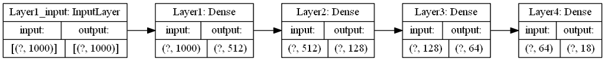

```python
model = keras.Sequential(name = "Keras_NLP_Model")
model.add(layers.Dense(512, input_dim= X_train.shape[1], kernel_initializer='uniform', activation='relu', name='Layer1'))
model.add(layers.Dense(128, kernel_initializer='uniform', activation='sigmoid', name='Layer2'))
model.add(layers.Dense(64, kernel_initializer='uniform', activation='sigmoid', name='Layer3'))
model.add(layers.Dense(y_train.shape[1], kernel_initializer='uniform', activation='sigmoid', name='Layer4'))
model.summary()
keras.utils.plot_model(model, show_shapes=True, show_layer_names=True, expand_nested = True, rankdir = 'LR')
```

```python
# Number of iterations
IT = 6

model.compile(optimizer='rmsprop', loss='categorical_crossentropy', metrics=['accuracy','mae', 'mse'])


# Train model
history = model.fit(X_train, y_train, validation_data=(X_test, y_test), epochs= IT, batch_size=32, verbose = 0)
```

```python
def Search_List(Key, List): return [s for s in List if Key in s]

Metrics_Names = {'loss':'Loss', 'accuracy':'Accuracy', 'mae':'MAE', 'mse':'MSE'}

def Table_modify(df, Metrics_Names = Metrics_Names):
    df = df.rename(columns = Metrics_Names)
    df = df.reindex(sorted(df.columns), axis=1)
    df.insert(loc = 0, column = 'Iteration', value = np.arange(0, df.shape[0]), allow_duplicates=False)
    return df

Validation_Table = Search_List('val_',history.history.keys())
Train_Table = list(set( history.history.keys()) - set(Validation_Table))
Validation_Table = pd.DataFrame(np.array([history.history[x] for x in Validation_Table]).T, columns = Validation_Table)
Train_Table = pd.DataFrame(np.array([history.history[x] for x in Train_Table]).T, columns = Train_Table)
Validation_Table.columns = [x.replace('val_','') for x in Validation_Table.columns]

Train_Table = Table_modify(Train_Table)
Validation_Table = Table_modify(Validation_Table)

# Train Set Score
score = model.evaluate(X_test, y_test, batch_size=128, verbose = 0)
score = pd.DataFrame(score, index = model.metrics_names).T
score.index = ['Train Set Score']
# Validation Set Score
Temp = model.evaluate(X_train, y_train, batch_size=128, verbose = 0)
Temp = pd.DataFrame(Temp, index = model.metrics_names).T
Temp.index = ['Validation Set Score']
score = score.append(Temp)
score.rename(columns= Metrics_Names, inplace = True)
score = score.reindex(sorted(score.columns), axis=1)
display(score.style.set_precision(4))
```

|  | Accuracy | Loss | MAE | MSE |
| --- | --- | --- | --- | --- |
| Train Set Score | 0.7709 | 0.7595 | 0.0556 | 0.0556 |
| Validation Set Score | 0.7984 | 0.6617 | 0.0556 | 0.0556 |

```python
def Plot_history(history, Title = False, Table_Rows = 25, YL = 1):
    fig = make_subplots(rows=1, cols=2, horizontal_spacing = 0.02, column_widths=[0.6, 0.4],
                        specs=[[{"type": "scatter"},{"type": "table"}]])
    # Left
    fig.add_trace(go.Scatter(x= history['Iteration'].values, y= history['Loss'].values,
                             line=dict(color='OrangeRed', width= 1.5), name = 'Loss'), 1, 1)
    fig.add_trace(go.Scatter(x= history['Iteration'].values, y= history['Accuracy'].values,
                             line=dict(color='MidnightBlue', width= 1.5),  name = 'Accuracy'), 1, 1)
    fig.add_trace(go.Scatter(x= history['Iteration'].values, y= history['MAE'].values,
                             line=dict(color='ForestGreen', width= 1.5), name = 'Mean Absolute Error (MAE)'), 1, 1)
    fig.add_trace(go.Scatter(x= history['Iteration'].values, y= history['MSE'].values,
                             line=dict(color='purple', width= 1.5), name = 'Mean Squared Error (MSE)'), 1, 1)
    fig.update_layout(legend=dict(x=0, y=1.1, traceorder='reversed', font_size=12),
                  dragmode='select', plot_bgcolor= 'white', height=600, hovermode='closest',
                  legend_orientation='h')
    fig.update_xaxes(range=[history.Iteration.min(), history.Iteration.max()],
                     showgrid=True, gridwidth=1, gridcolor='Lightgray',
                     showline=True, linewidth=1, linecolor='Lightgray', mirror=True, row=1, col=1)
    fig.update_yaxes(range=[0, YL], showgrid=True, gridwidth=1, gridcolor='Lightgray',
                     showline=True, linewidth=1, linecolor='Lightgray', mirror=True, row=1, col=1)
    # Right
    ind = np.linspace(0, history.shape[0], Table_Rows, endpoint = False).round(0).astype(int)
    ind = np.append(ind, history.Iteration.values[-1])
    history = history[history.index.isin(ind)]
    Temp = []
    for i in history.columns:
        Temp.append(history.loc[:,i].astype(float).round(4).values)
    fig.add_trace(go.Table(header=dict(values = list(history.columns), line_color='darkslategray',
                                       fill_color='DimGray', align=['center','center'],
                                       font=dict(color='white', size=12), height=25), columnwidth = [0.4, 0.4, 0.4, 0.4],
                           cells=dict(values=Temp, line_color='darkslategray', fill=dict(color=['WhiteSmoke', 'white']),
                                      align=['center', 'center'], font_size=12,height=20)), 1, 2)
    if Title != False:
        fig.update_layout(plot_bgcolor= 'white',
                      title={'text': Title, 'x':0.46, 'y':0.94, 'xanchor': 'center', 'yanchor': 'top'},
                          yaxis_title='Frequency')
    fig.show()

def Header(Text, L = 100, C = 'Blue', T = 'White'):
    BACK = {'Black': Back.BLACK, 'Red':Back.RED, 'Green':Back.GREEN, 'Yellow': Back.YELLOW, 'Blue': Back.BLUE,
         'Magenta':Back.MAGENTA, 'Cyan': Back.CYAN}
    FORE = {'Black': Fore.BLACK, 'Red':Fore.RED, 'Green':Fore.GREEN, 'Yellow':Fore.YELLOW, 'Blue':Fore.BLUE,
         'Magenta':Fore.MAGENTA, 'Cyan':Fore.CYAN, 'White': Fore.WHITE}
    print(BACK[C] + FORE[T] + Style.NORMAL + Text + Style.RESET_ALL + ' ' + FORE[C] +
          Style.NORMAL +  (L- len(Text) - 1)*'=' + Style.RESET_ALL)

def Line(L=100, C = 'Blue'):
    FORE = {'Black': Fore.BLACK, 'Red':Fore.RED, 'Green':Fore.GREEN, 'Yellow':Fore.YELLOW, 'Blue':Fore.BLUE,
         'Magenta':Fore.MAGENTA, 'Cyan':Fore.CYAN, 'White': Fore.WHITE}
    print(FORE[C] + Style.NORMAL + L*'=' + Style.RESET_ALL)
```

```python
Plot_history(Train_Table, Title = 'Train Set', YL = 1.2)
Plot_history(Validation_Table, Title = 'Validation Set')
```

[interactive chart not shown]

Testing the results.

```python
# Picking a random sample
Ind = np.random.randint(X_test.shape[0], size=15)
Line()
for i in Ind:
    Pred = model.predict(np.array([X_test[i]]))
    Pred = encoder.classes_[np.argmax(Pred)]
    print(Back.MAGENTA + Fore.BLACK + Style.BRIGHT + 'Narrative:' + Style.RESET_ALL + ' %s ...' %
          test['Consumer complaint narrative'].values[i][:80])
    print(Back.CYAN + Fore.BLACK + Style.BRIGHT + 'Label (Actual):' + Style.RESET_ALL + ' %s' % test['Product'].values[i])
    print(Back.GREEN + Fore.BLACK + Style.BRIGHT + 'Label (Predicted):' + Style.RESET_ALL + ' %s' % Pred)
    Line()

del Ind, Pred
```

```
====================================================================================================
Narrative: On XX/XX/XXXX XXXX  XXXX accessed my credit file with Transunion, XXXX, AND XXXX ...
Label (Actual): Credit reporting, credit repair services, or other personal consumer reports
Label (Predicted): Credit reporting, credit repair services, or other personal consumer reports
====================================================================================================
Narrative: This complaint is on behalf of our client regarding their mortgage with Citi. We ...
Label (Actual): Mortgage
Label (Predicted): Mortgage
====================================================================================================
Narrative: I am the spouse of the primary holder of a Discover credit card. I am an authori ...
Label (Actual): Credit card
Label (Predicted): Credit card
====================================================================================================
Narrative: On XX/XX/XXXX, XXXX XXXX XXXX, Human Resources Department received an unsolicite ...
Label (Actual): Debt collection
Label (Predicted): Debt collection
====================================================================================================
Narrative: In XX/XX/XXXX, I filed a prior complaint with the CFPB, number XXXX, regarding P ...
Label (Actual): Student loan
Label (Predicted): Mortgage
====================================================================================================
Narrative: XXXX XXXX XXXX reported me as making a late payment to the credit bureau, when I ...
Label (Actual): Credit reporting, credit repair services, or other personal consumer reports
Label (Predicted): Credit reporting, credit repair services, or other personal consumer reports
====================================================================================================
Narrative: I am XXXX member since XXXX. I am writing regarding my unpleasant reservation ex ...
Label (Actual): Credit card or prepaid card
Label (Predicted): Money transfer, virtual currency, or money service
====================================================================================================
Narrative: I'm writing in regards to my car loan with First Hawaiian Bank ( FHB ). I paid o ...
Label (Actual): Vehicle loan or lease
Label (Predicted): Payday loan, title loan, or personal loan
====================================================================================================
Narrative: I submitted a dispute to all 3 credit bureaus ( XXXX, TransUnion and XXXX  ) on  ...
Label (Actual): Credit reporting, credit repair services, or other personal consumer reports
Label (Predicted): Credit reporting, credit repair services, or other personal consumer reports
====================================================================================================
Narrative: EQUIFAX HAS RECENTLY VIOLATED THE F.C.R.A., ILLEGALLY DEPICTING XXXX XXXX  ACCOU ...
Label (Actual): Credit reporting, credit repair services, or other personal consumer reports
Label (Predicted): Credit reporting, credit repair services, or other personal consumer reports
```

[output cut: 9 more lines]

```
Narrative: We have repeatedly contacted Bank of America and have received zero help. They w ...
Label (Actual): Checking or savings account
Label (Predicted): Bank account or service
====================================================================================================
Narrative: This company put medical debt on my credit report causing irreparable damage to  ...
Label (Actual): Debt collection
Label (Predicted): Debt collection
====================================================================================================
Narrative: I have tried to collect my credit report from Equifax and XXXX XXXX.


Both the ...
Label (Actual): Credit reporting, credit repair services, or other personal consumer reports
Label (Predicted): Credit reporting
====================================================================================================
```

# References

1. [Consumer Complaint Database](https://catalog.data.gov/dataset/consumer-complaint-database)
2. [Kaggle Dataset: US Consumer Finance Complaints](https://www.kaggle.com/cfpb/us-consumer-finance-complaints)